# Virus_sequences_per_virus_and_host

Mark Stenglein

1/4/2022

## Overview

This documents an analysis of the number of virus sequences per viral taxon and per host taxon. I undertook this analysis because I was interested in quantifying the extent to which virology has focused on certain hosts and viruses. This analysis is described in a review article published in [Annual Review of Virology](https://www.annualreviews.org/journal/virology).

### Obtain virus sequence metadata

[NCBI Virus](https://www.ncbi.nlm.nih.gov/labs/virus/vssi/#/) is “is a community portal for viral sequence data”. It is described in [this paper](https://pubmed.ncbi.nlm.nih.gov/27899678/). Through this portal it is possible to download virus sequences or metadata about virus sequences. I downloaded all available metadata for all available virus nucleotide sequences.

Below are the steps I took to download this metadata. This produced a file of 2.2 Gb, which is too large to upload to the [GitHub repository](https://github.com/stenglein-lab/2022_Annual_Review_of_Virology) for this analysis.  
If you want to reproduce or update this analysis, you will have to follow these steps to download a copy of this metadata for yourself.

**To download virus sequence metadata:**

- Go to: [https://www.ncbi.nlm.nih.gov/labs/virus/vssi/#/virus?SeqType_s=Nucleotide](https://www.ncbi.nlm.nih.gov/labs/virus/vssi/#/virus?SeqType_s=Nucleotide%5D)
- Click: Download
- Select: Current Table View Results -> CSV format
- Select: Download all Records
- Click: on checkboxes for all columns
- Click: Download

When I did this on Jan 4, 2022, I downloaded a 2.2 Gb comma separated value (csv) file named `sequences.csv` with 6.8M lines (one line per virus sequence)

```bash
wc -l sequences.csv
```

```
##  6811567 sequences.csv
```

Get a checksum

```bash
md5 sequences.csv
```

```
## MD5 (sequences.csv) = dcafece3edf0407089a363e3a65abd37
```

List file

```bash
ls -l sequences.csv
```

```
## -rw-r--r--@ 1 mdstengl  staff  2396680404 Jan  4 12:04 sequences.csv
```

### Load R packages

```r
# load R libraries
# if these aren't installed, you will need to install them using install.packages()
library(tidyverse)
library(taxizedb)
library(taxize)
library(patchwork)
# dump all session information in the interest of reproducibility
```

[output not shown]

### Read in the metadata

```r
# read in the csv of virus sequence info from NCBI Virus
df <- read.csv("sequences.csv", stringsAsFactors = F, strip.white = T)

# how many sequences are there?
virus_sequences <- nrow(df)

print(paste0("There is metadata for: ", virus_sequences, " virus sequences."))
```

```
## [1] "There is metadata for: 6811566 virus sequences."
```

### Download NCBI taxonomy info

This analysis takes advantage of a couple really nice R packages that allow you to interact with the NCBI Taxonomy database (and other taxonomy resources). These are the [taxize](https://docs.ropensci.org/taxize/) and [taxizedb](https://docs.ropensci.org/taxizedb/) [R packages](https://taxize.dev/). Both of these were authored by Scott Chamberlain and colleagues. The main difference between the two packages is that taxizedb downloads a local copy of databases whereas taxize uses web queries to get at the data. taxizedb uses up more space on your hard drives but is faster after an initial download: web queries to NCBI are throttled to 10 per second, for example. taxizedb is not quite as fully featured as taxize, though, so this analysis uses both packages.

### Download local copy of NCBI Taxonomy database

The code chunk below downloads a local copy of the NCBI taxonomy database and puts it in a sqlite database. If you’ve not done this before, this will take a while to download. If you have downloaded it previously, this function will just return the path to the local NCBI database because overwrite is set to FALSE. If you want to update the database to the newest available version change overwrite to TRUE.

```r
ncbi_tax_db <- db_download_ncbi(verbose = TRUE, overwrite = FALSE)
```

```
## Database already exists, returning old file
```

### How long would a book have to be now to hold all of the available virus sequences?

This code block produces text that is part of the caption for Figure 2 in the review article.

```r
# how many bases of virus sequences?
# sum all of the sequence lengths
bases_of_virus_sequence <- df %>% summarize(bases = sum(Length)) %>% pull(bases)

# This estimate is based on the number of bases of sequence displayed per page in the 1985 Nucleotide Sequences book I have.
bases_per_book_page <- 3000

# define a printf helper function
printf <- function(...) invisible(print(sprintf(...)))

# make sentence for paper:
printf("Now, the %0.1e bases of virus sequence would need a book %0.0f million pages long to fit all of the virus sequences.",
                      bases_of_virus_sequence, (bases_of_virus_sequence / bases_per_book_page / 1e6 ))
```

```
## [1] "Now, the 9.9e+10 bases of virus sequence would need a book 33 million pages long to fit all of the virus sequences."
```

### How many of the sequences have an annotated host?

Not all sequences have an annotated host.

```r
# only keep records with annotated host information
df_host <- filter(df, str_length(Host) > 0)

# calculate fraction of sequences with host annotation
num_seqs_with_host = nrow(df_host)
pct_seqs_with_host = (num_seqs_with_host / virus_sequences) * 100

# output text for paper
printf("for instance, only %0.1e of the %0.1e viral sequences (%0.0f%%) have an annotated host", nrow(df_host), nrow(df), pct_seqs_with_host)
```

```
## [1] "for instance, only 6.2e+06 of the 6.8e+06 viral sequences (91%) have an annotated host"
```

### Get latin binomials for host taxa

The host annotation associated with virus sequences in NCBI is not all that standardized. Basically, it’s whatever the sequence depositors decided to label the host as. I will try to be as systematic as possible by using the first two words of the host annotation field, with the assumption that for most sequences this corresponds to the host Latin binomial (e.g. Homo sapiens).

Not all host annotations are a latin binomial. Some are higher order taxa. For instance some virus sequences are assigned to higher order taxa (if, for instance, they are from a pool of related organisms as in Genbank record KX884152, the host of which is Diptera). Some host names have changed over time. So there is some uncertainty associated with assigning hosts to virus sequences.

But one nice thing about taxize and the NCBI database is that it is possible to use host synonyms (human is a synonym of Homo sapiens), and for this anlaysis it’ll be OK to assign to higher order taxa: we will just count each higher order taxon as one of all the host taxa.

```r
# pull out host binomial name, assumed to be the first and second words of host name
df_host_binomial_df <-  as.data.frame(str_extract_all(df_host$Host, "\\S+", simplify = T)[,1:2])
df_host$binomial   <- df_host_binomial_df %>% mutate(host_binomial = str_trim(paste(V1, V2, sep=" "))) %>% pull(host_binomial)

# now need to map host genus name to the NCBI taxonomic tree
# collect all the unique binomials
df_binomial <- df_host %>% group_by(binomial) %>% summarize()

# convert binomial names to taxids using taxizedb name2taxid function
# this function will deal with old names and taxon synonyms, like human -> Homo sapiens
df_binomial_taxid <- taxizedb::name2taxid(df_binomial$binomial, out_type="summary")

# output the top of this table
head(df_binomial_taxid)
```

```
## # A tibble: 6 × 2
##   name                    id
##   <chr>                   <chr>
## 1 [Brevibacterium] flavum 92706
## 2 [Ruminococcus] gnavus   33038
## 3 Abelmoschus             183218
## 4 Abelmoschus angulosus   1610808
## 5 Abelmoschus caillei     1401368
## 6 Abelmoschus esculentus  455045
```

### Deal with ambiuous host names

name2taxid() does not necessarily return a single taxid for each name. Any name that produces >1 taxid is ambiguous. We need to deal with those.

A common reason this happens is when a genus and subgenus have the same name. For example, Aedes is both a genus and subgenus of mosquito. name2taxid() returns taxids for *both* the genus and subgenus.

In other cases, taxon names are just ambiguous, sometimes even from different kingdoms. As an example, Alpinia is both a genus of beetle and of plant.

The way we will deal with these ambiguous taxids is to assign the sequence to the lowest common ancestor (LCA) of the taxids for that name. For instance, the name “Aedes” will return taxids 149531 (the subgenus Aedes) and 7158 (the genus Aedes). The LCA of these is the genus Aedes, taxid 7158.

In more ambguous cases (e.g. Alpinia), the LCA may be near the root of the taxonomic tree and so not that useful.

```r
# pull out any taxon names that were ambiguous, i.e. that had >1 taxid assigned
df_ambig <- df_binomial_taxid %>% group_by(name) %>% filter(n() > 1)

# collapse rows from an ambiguous name -> taxid conversion
# and only keep a lowest common ancestor taxid
#
# note that if you want this to run faster, you should set your ENTREZ_KEY R environmental variable
# If this is not set, taxize will issue warnings if not and your queries will be more throttled
#
# do this by commenting out and running the command below.
# Sys.setenv(ENTREZ_KEY = "Your-NCBI_API_token")
# or putting your NCBI entrey key in in a .Renviron file in your home directory

# this function uses the taxize::lowest_common function to identify taxonomic lowest common ancestor
# for a set of taxids in a way that is compatible with group_modify() below

# turn off noisy taxize output
taxize_options(taxon_state_messages = F, quiet=T)

# have to use taxize we queries and not taxizedb local queries because taxizedb doesn't have lowest_common function.
#
return_lca <- function (x,y) {
  ids <- as.integer(x$id)
  lca <- taxize::lowest_common(ids, db="ncbi")
  new_row = data.frame(id = lca$id)
  # throttle to 10 per second to comply with NCBI query rate limit
  Sys.sleep(0.1)
  new_row
}

# determine lca for all ambiguous taxon names

# group_modify is a cool/funky dplyr function.  It takes a grouped dataframe and runs a function on the
# subset of the dataframe for each group, and returns a dataframe.  For more info, see:
# https://dplyr.tidyverse.org/reference/group_map.html
#
# Here, we will group by name (so names with multiple taxids will form one group)
# and the return_lca function will return a single row for each of these multi-row
# groups that has the name and LCA taxid.
df_lca <- df_ambig %>% group_by(name) %>% group_modify(~ return_lca(.x))
df_lca <- df_lca %>% ungroup()

# these are the host taxa names that were unambiguously assigned to taxids
df_no_ambig <- df_binomial_taxid %>% group_by(name) %>% filter(n() == 1) %>% ungroup()

# concatenate unambigious taxon names plus de-ambiguated ones
df_taxid <- rbind(df_no_ambig, df_lca)

# give these taxids "official" taxon names from the host taxid
df_taxid <- df_taxid %>% mutate(host_taxon_name = taxizedb::taxid2name(id))

# merge in host taxon data to the big df
df_host <- left_join(df_host, df_taxid, by=c("binomial" = "name"))

# rename id column -> host_taxid
df_host <- df_host %>% rename(host_taxid = id)

# show solume colums from the first rows
head(select(df_host, Accession, Species, Host, host_taxid))
```

```
##     Accession                            Species
## 1 NC_052974.1 Achromobacter phage vB_AchrS_AchV4
## 2 NC_052978.1                 Proteus phage Saba
## 3 NC_055956.1              Klebsiella phage RAD2
## 4 NC_056724.1             Lactococcus virus BK5T
## 5 NC_055706.1    Azobacteroides phage ProJPt-Bp1
## 6 NC_055707.1             Mycobacterium phage HC
##                                            Host host_taxid
## 1                                 Achromobacter        222
## 2                             Proteus mirabilis        584
## 3                         Klebsiella pneumoniae        573
## 4                                   Lactococcus       1357
## 5 Candidatus Azobacteroides pseudotrichonymphae     511434
## 6                                 Mycobacterium       1763
```

### Get virus taxon information

Now we will get information about virus sequences species (or higher order taxon). Virus species names are systematically linked to Taxonomy taxids, so this is more straightforward then host annotation to taxid coversions.

```r
# -------------------------
# get virus species taxids
# -------------------------

# get all of the unique viral taxa
df_unique_virus_spp <- df_host %>% group_by(Species) %>% summarize()

# convert these into taxids
df_virus_taxid <- taxizedb::name2taxid(df_unique_virus_spp$Species, out_type="summary")

# these *should* be unambiguously assigned
df_virus_ambig <- df_virus_taxid %>% group_by(name) %>% summarize(n=n()) %>% filter(n > 1)
if (nrow(df_virus_ambig) > 0) {
  message("Error: some virus species name were ambiguously assigned")
  message(head(df_virus_ambig))
  stop("Exiting...")
}

# rename the column that has virus taxid
df_virus_taxid <- df_virus_taxid %>% rename(virus_taxid = id)

# merge in virus taxid column
df_host <- left_join(df_host, df_virus_taxid, by=(c("Species" = "name")))

# show solume colums from the first rows
head(select(df_host, Accession, Species, virus_taxid))
```

```
##     Accession                            Species virus_taxid
## 1 NC_052974.1 Achromobacter phage vB_AchrS_AchV4     2796514
## 2 NC_052978.1                 Proteus phage Saba     2596672
## 3 NC_055956.1              Klebsiella phage RAD2     2831671
## 4 NC_056724.1             Lactococcus virus BK5T     2845191
## 5 NC_055706.1    Azobacteroides phage ProJPt-Bp1     1920526
## 6 NC_055707.1             Mycobacterium phage HC     2077135
```

## Output tables

### Table of sequences per host

OK, now we have the data in the format we want. Let’s output some tables

```r
# ---------------------------------------------------
# Output info on hosts with most sequenced viruses
# ---------------------------------------------------

output_seqs_per_host <- function(df_host, filename, number_to_output)  {

  # calculate sequences per host taxon and arrange in descending order
  seqs_per_host <- df_host %>%
    group_by(host_taxon_name) %>%
    summarize(seqs_per_host = n(), .groups="drop") %>%
    arrange(-seqs_per_host) %>%
    # calculate rank (order) and fraction of all sequences
    mutate(rank = row_number(),
           fraction_seqs = seqs_per_host / nrow(df_host),
       cumulative_fraction_seqs = cumsum(fraction_seqs))

  # prepare a table for output
  # only keep top rows
  hosts_for_output <- head(seqs_per_host, number_to_output)

  # collect common names for hosts using the taxize sci2comm function (not available in taxizedb)
  # I don't know how to surpress status messages from sci2comm: taxize_options() doesn't work
  common_names_list <- taxize::sci2comm(hosts_for_output$host_taxon_name, db='ncbi')

  # convert list to dataframe and rename columns
  common_names <- as.data.frame(do.call(rbind,common_names_list))
  common_names <- common_names %>% mutate(host_taxon_name = row.names(common_names), common_name = V1) %>% select(-V1)
  row.names(common_names) <- NULL

  # merge in common names
  hosts_for_output <- left_join(hosts_for_output, common_names)

  # reformat output
  hosts_for_output <-
    hosts_for_output %>%
    mutate(k_virus_seqs = sprintf("%0.1f", seqs_per_host/1000),
           pct_seqs = sprintf("%0.1f", fraction_seqs * 100),
           cumulative_pct = sprintf("%0.1f", cumulative_fraction_seqs * 100)) %>%
    select(host_taxon_name, common_name, k_virus_seqs, pct_seqs, cumulative_pct)

  # write out a text file
  write.table(hosts_for_output, filename, quote=F, sep="\t", row.names=F)

  # return the table
  hosts_for_output
}
```

```r
# Do this this way, with this call in a separate code block
# because taxize::sci2comm produces really long and not-turnoffable
# status messages, so run this in a output-supressed code block
# so those messages don't show up in knit output
host_tab <- output_seqs_per_host(df_host, "top_virus_hosts.txt", 20)
```

```r
host_tab
```

```
## # A tibble: 20 × 5
##    host_taxon_name      common_name        k_virus_seqs pct_seqs cumulative_pct
##    <chr>                <fct>              <chr>        <chr>    <chr>
##  1 Homo sapiens         human              5224.4       84.7     84.7
##  2 Sus scrofa           pig                178.9        2.9      87.6
##  3 Gallus gallus        chicken            93.3         1.5      89.1
##  4 Anas platyrhynchos   mallard            50.2         0.8      89.9
##  5 Bos taurus           cattle             45.9         0.7      90.7
##  6 Macaca mulatta       Rhesus monkey      34.9         0.6      91.2
##  7 Anatidae             waterfowl          31.7         0.5      91.7
##  8 Simiiformes          <NA>               20.9         0.3      92.1
##  9 Canis lupus          gray wolf          20.2         0.3      92.4
## 10 Equus caballus       horse              17.7         0.3      92.7
## 11 Arenaria interpres   ruddy turnstone    13.6         0.2      92.9
## 12 Ovis aries           sheep              10.1         0.2      93.1
## 13 Aves                 birds              9.3          0.2      93.2
## 14 Vitis vinifera       wine grape         8.9          0.1      93.4
## 15 Solanum lycopersicum tomato             8.6          0.1      93.5
## 16 Spatula discors      blue-winged teal   8.4          0.1      93.6
## 17 Felis catus          domestic cat       8.0          0.1      93.8
## 18 Anas acuta           northern pintail   6.5          0.1      93.9
## 19 Meleagris gallopavo  turkey             6.0          0.1      94.0
## 20 Macaca nemestrina    pig-tailed macaque 5.5          0.1      94.1
```

### Output tables of most-sequenced viruses

```r
# ----------------------------------------
# Output info on most-sequenced viruses
# ----------------------------------------

# tabulate virus info

# count # of sequences per virus taxon
# arrange in descending order
# calculate fractional counts
output_seqs_per_virus <- function(df_host, filename, number_to_output) {
  seqs_per_virus <- df_host %>%
    group_by(Species) %>%
    summarize(seqs_per_virus = n(), .groups="drop") %>%
    arrange(-seqs_per_virus) %>%
    mutate(rank = row_number(),
           fraction_seqs = seqs_per_virus / nrow(df_host),
           cumulative_fraction_seqs = cumsum(fraction_seqs))

  # prepare a table for output
  viruses_for_output <- head(seqs_per_virus, number_to_output)

  # reformat output
  viruses_for_output <-
    viruses_for_output %>%
    mutate(k_virus_seqs = sprintf("%0.1f", seqs_per_virus/1000),
           pct_seqs = sprintf("%0.1f", fraction_seqs * 100),
           cumulative_pct = sprintf("%0.1f", cumulative_fraction_seqs * 100)) %>%
    select(Species, k_virus_seqs, pct_seqs, cumulative_pct)

  # write out a text file
  write.table(viruses_for_output, filename, quote=F, sep="\t", row.names=F)

  #output here too
  viruses_for_output
}

output_seqs_per_virus(df_host, "top_viruses.txt", 20)
```

```
## # A tibble: 20 × 4
##    Species                                  k_virus_seqs pct_seqs cumulative_pct
##    <chr>                                    <chr>        <chr>    <chr>
##  1 Severe acute respiratory syndrome-relat… 3036.1       49.2     49.2
##  2 Human immunodeficiency virus 1           985.5        16.0     65.2
##  3 Influenza A virus                        725.9        11.8     77.0
##  4 Hepacivirus C                            155.0        2.5      79.5
##  5 Influenza B virus                        112.0        1.8      81.3
##  6 Hepatitis B virus                        89.0         1.4      82.7
##  7 Rotavirus A                              85.0         1.4      84.1
##  8 Simian immunodeficiency virus            49.4         0.8      84.9
##  9 Norwalk virus                            37.3         0.6      85.5
## 10 Enterovirus A                            32.0         0.5      86.0
## 11 Dengue virus                             31.6         0.5      86.5
## 12 Porcine reproductive and respiratory sy… 27.6         0.4      87.0
## 13 Human orthopneumovirus                   25.6         0.4      87.4
## 14 Rabies lyssavirus                        22.4         0.4      87.8
## 15 Pestivirus A                             18.5         0.3      88.1
## 16 Enterovirus B                            18.4         0.3      88.4
## 17 Measles morbillivirus                    16.9         0.3      88.6
## 18 Orthohepevirus A                         16.4         0.3      88.9
## 19 Simian-Human immunodeficiency virus      16.3         0.3      89.2
## 20 Human immunodeficiency virus             15.4         0.2      89.4
```

### Remove most-sequenced pandemic viruses

Pandemic viruses account for the most-sequenced viruses. What if we remove them from analysis? I will remove sequences from sarbecoviruses, lentiviruses, and influenza viruses and make simlar tables.

```r
# ------------------------------------------------------
# Remove most-sequenced viruses and analyze remaining
# -----------------------------------------------------

# Do this analysis but without sarbecovirus, orthomyxovirus, or lentivirus sequences

# Manually looked up taxids for these genera

sarbecovirus_taxid <- 2509511
# alpha, beta, gamma, deltainfluenza virus taxids
influenzavirus_taxids <- c(197911, 197912, 197913, 1511083)
lentivirus_taxid <- 11646

parental_taxids_to_filter <- c(sarbecovirus_taxid, influenzavirus_taxids, lentivirus_taxid)

# get all taxa downstream of these parent taxids as well.
# So we can filter out any sequence that comes from any of these parent taxids or any of their child taxids.
downstream_taxids <- taxizedb::downstream(parental_taxids_to_filter)

# downstream returns a somewhat complicated list data structure
# with list elements named by the original query taxids
# and then each of them having childtaxa_id elements
# that are character vectors of all the downstream child taxids
#
# need this function to get those downstream taxids out of that structure
get_child_taxids <- function(x) {
  x$childtaxa_id
}

# this will be a long list of all parent and downstream taxids that we will remove
taxids_to_filter <- unlist(lapply(downstream_taxids, get_child_taxids), use.names = F)

# concatenate child and parental taxids in case any sequences annotated to host at the parental (genus) level
taxids_to_filter <- c(taxids_to_filter, parental_taxids_to_filter)

# filter out any virus from any of those taxids
df_host_filtered <- df_host %>% filter(!(virus_taxid %in% taxids_to_filter))

# how many sequences remaining (%)?
frac_after_filtering_pandemic_viruses <- nrow(df_host_filtered) / nrow(df_host)
pct_pandemic_virus_sequences = (1-frac_after_filtering_pandemic_viruses) * 100

# output text for paper
printf(paste0("Together, sequences from sarbecoviruses (SARS-CoV-2 and related viruses), ",
              "lentiviruses (HIV and related viruses), and influenza viruses account for ",
              "%0.1f%% of all virus sequences."),  pct_pandemic_virus_sequences)
```

```
## [1] "Together, sequences from sarbecoviruses (SARS-CoV-2 and related viruses), lentiviruses (HIV and related viruses), and influenza viruses account for 80.4% of all virus sequences."
```

### Output tables with pandemic virus sequences removed

```r
# output tables as above
host_tab_no_pandemic <- output_seqs_per_host(df_host_filtered, "top_viruses_hosts_filtered.txt", 20)
```

```r
host_tab_no_pandemic
```

```
## # A tibble: 20 × 5
##    host_taxon_name       common_name     k_virus_seqs pct_seqs cumulative_pct
##    <chr>                 <fct>           <chr>        <chr>    <chr>
##  1 Homo sapiens          human           685.9        56.8     56.8
##  2 Sus scrofa            pig             77.3         6.4      63.2
##  3 Bos taurus            cattle          44.7         3.7      66.9
##  4 Gallus gallus         chicken         26.5         2.2      69.1
##  5 Canis lupus           gray wolf       16.7         1.4      70.5
##  6 Vitis vinifera        wine grape      8.9          0.7      71.3
##  7 Solanum lycopersicum  tomato          8.6          0.7      72.0
##  8 Equus caballus        horse           7.0          0.6      72.6
##  9 Ovis aries            sheep           6.3          0.5      73.1
## 10 Felis catus           domestic cat    6.2          0.5      73.6
## 11 Apis mellifera        honey bee       4.9          0.4      74.0
## 12 Solanum tuberosum     potato          4.6          0.4      74.4
## 13 Sus                   <NA>            4.6          0.4      74.8
## 14 Salmo salar           Atlantic salmon 4.1          0.3      75.1
## 15 Prunus persica        peach           4.1          0.3      75.5
## 16 Capra hircus          goat            3.5          0.3      75.7
## 17 Macaca mulatta        Rhesus monkey   3.4          0.3      76.0
## 18 Manihot esculenta     cassava         3.1          0.3      76.3
## 19 Oryctolagus cuniculus rabbit          3.1          0.3      76.5
## 20 <NA>                  <NA>            3.0          0.3      76.8
```

```r
output_seqs_per_virus(df_host_filtered, "top_viruses_filtered.txt", 20)
```

```
## # A tibble: 20 × 4
##    Species                                  k_virus_seqs pct_seqs cumulative_pct
##    <chr>                                    <chr>        <chr>    <chr>
##  1 Hepacivirus C                            155.0        12.8     12.8
##  2 Hepatitis B virus                        89.0         7.4      20.2
##  3 Rotavirus A                              85.0         7.0      27.3
##  4 Norwalk virus                            37.3         3.1      30.4
##  5 Enterovirus A                            32.0         2.7      33.0
##  6 Dengue virus                             31.6         2.6      35.6
##  7 Porcine reproductive and respiratory sy… 27.6         2.3      37.9
##  8 Human orthopneumovirus                   25.6         2.1      40.0
##  9 Rabies lyssavirus                        22.4         1.9      41.9
## 10 Pestivirus A                             18.5         1.5      43.4
## 11 Enterovirus B                            18.4         1.5      44.9
## 12 Measles morbillivirus                    16.9         1.4      46.3
## 13 Orthohepevirus A                         16.4         1.4      47.7
## 14 Alphapapillomavirus 9                    15.3         1.3      49.0
## 15 Mumps orthorubulavirus                   10.8         0.9      49.9
## 16 Foot-and-mouth disease virus             10.2         0.8      50.7
## 17 Avian coronavirus                        9.7          0.8      51.5
## 18 Avian orthoavulavirus 1                  8.0          0.7      52.2
## 19 Enterovirus C                            7.4          0.6      52.8
## 20 Porcine circovirus 2                     7.0          0.6      53.4
```

### Make plots

Now going to cumulative distribution graphs of virus sequences vs. viral and host taxa (Figure 1 of review article).

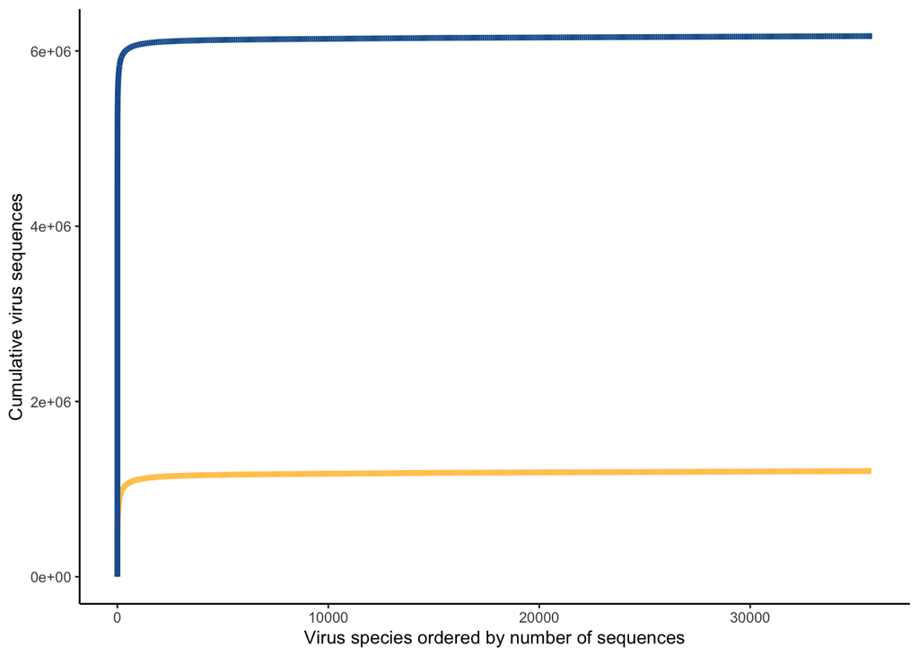

```r
# -------------------------------------------------------
# Plot cumulative curves for virus sequences per species
# -------------------------------------------------------

# the code below makes 4 data frames with hosts and viruses ordered by their # of virus sequences and with a column
# that contains the cumulative # of virus sequences
#
# do this for all virus sequences and with pandemic sequences removed.
seqs_per_virus <- df_host %>% group_by(Species) %>% summarize(seqs_per_virus = n(), .groups="drop") %>% arrange(-seqs_per_virus) %>%
  mutate(rank = row_number(), cumulative_seqs = cumsum(seqs_per_virus))

seqs_per_virus_filtered <- df_host_filtered %>% group_by(Species) %>% summarize(seqs_per_virus = n(), .groups="drop") %>% arrange(-seqs_per_virus) %>%
  mutate(rank = row_number(), cumulative_seqs = cumsum(seqs_per_virus))

seqs_per_host <- df_host %>% group_by(host_taxid) %>% summarize(seqs_per_host = n(), .groups="drop") %>% arrange(-seqs_per_host) %>%
  mutate(rank = row_number(), cumulative_seqs = cumsum(seqs_per_host))

seqs_per_host_filtered <- df_host_filtered %>% group_by(host_taxid) %>% summarize(seqs_per_host = n(), .groups="drop") %>% arrange(-seqs_per_host) %>%
  mutate(rank = row_number(), cumulative_seqs = cumsum(seqs_per_host))

# make artificial zero points for plots (start plots at the origins)
zero_point_virus <- data.frame("StandIn", 0, 0, 0, stringsAsFactors=FALSE)
colnames(zero_point_virus) <- colnames(seqs_per_virus)

zero_point_host <- data.frame("StandIn", 0, 0, 0, stringsAsFactors=FALSE)
colnames(zero_point_host) <- colnames(seqs_per_host)

# merge in zero points
spv_plot <- rbind(zero_point_virus, seqs_per_virus)
spvf_plot <- rbind(zero_point_virus, seqs_per_virus_filtered)

sph_plot <- rbind(zero_point_host, seqs_per_host)
sphf_plot <- rbind(zero_point_host, seqs_per_host_filtered)

# fancy colors popular in 2022
skydiver <- rgb(31/255, 96/255, 158/255)
daffodil <- rgb(255/255, 199/255, 82/255)
glacier_lake <- rgb(132/255, 165/255, 188/255)

# Make the virus cumulative distribution plot
v_curve_p <- ggplot() +
  geom_line(data=spvf_plot, mapping=aes(x=rank, y=cumulative_seqs), size=1.5, color=daffodil) +
  geom_line(data=spv_plot, mapping=aes(x=rank, y=cumulative_seqs), size=1.5, color=skydiver) +
  # geom_area(data=spv_plot, mapping=aes(x=rank, y=cumulative_seqs), fill=skydiver, alpha=0.5) +
  # geom_area(data=spvf_plot, mapping=aes(x=rank, y=cumulative_seqs), fill=daffodil, alpha=0.5) +
  xlab("Virus species ordered by number of sequences") +
  ylab("Cumulative virus sequences") +
  theme_classic(base_size = 10)

v_curve_p
```

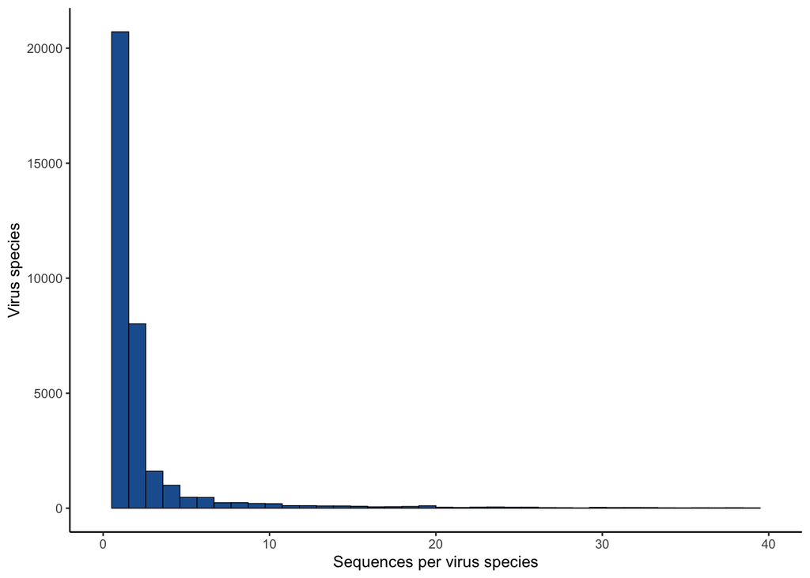

```r
# histogram of sequences per virus taxa
v_histo_p <- ggplot() +
  geom_histogram(data=spv_plot, mapping=aes(x=seqs_per_virus), bins=40, fill=skydiver, color="black", size=0.25) +
  xlab("Sequences per virus species") +
  ylab("Virus species") +
  # scale_y_log10() +
  xlim(c(0,40)) +
  theme_classic(base_size = 10)

v_histo_p
```

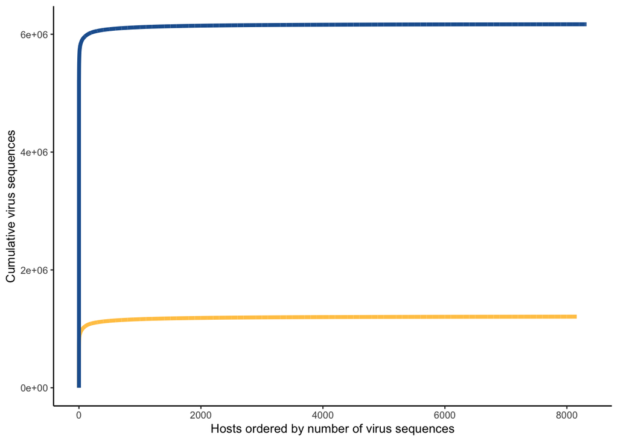

```r
# host cumulative distribution plot
h_curve_p <- ggplot() +
  geom_line(data=sphf_plot, mapping=aes(x=rank, y=cumulative_seqs), size=1.5, color=daffodil) +
  geom_line(data=sph_plot, mapping=aes(x=rank, y=cumulative_seqs), size=1.5, color=skydiver) +
  # geom_area(data=sph_plot, mapping=aes(x=rank, y=cumulative_seqs), fill=skydiver, alpha=0.5) +
  # geom_area(data=sphf_plot, mapping=aes(x=rank, y=cumulative_seqs), fill=daffodil, alpha=0.5) +
  xlab("Hosts ordered by number of virus sequences") +
  ylab("Cumulative virus sequences") +
  theme_classic(base_size = 10)

h_curve_p
```

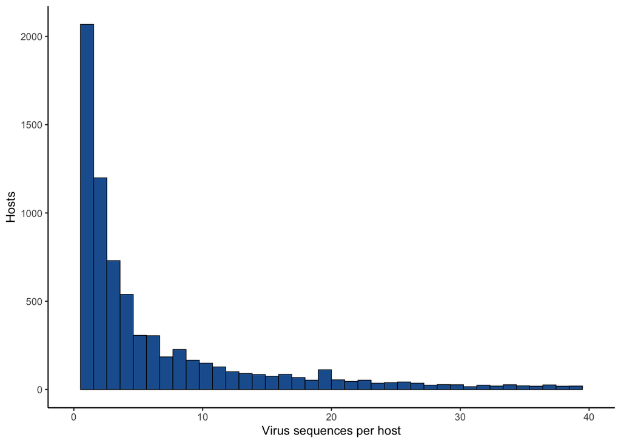

```r
# viruses per host histogram
h_histo_p <- ggplot() +
  geom_histogram(data=seqs_per_host, mapping=aes(x=seqs_per_host), bins=40, fill=skydiver, color="black", size=0.25) +
  xlab("Virus sequences per host") +
  ylab("Hosts") +
  # scale_y_log10() +
  xlim(c(0,40)) +
  theme_classic(base_size = 10)

h_histo_p
```

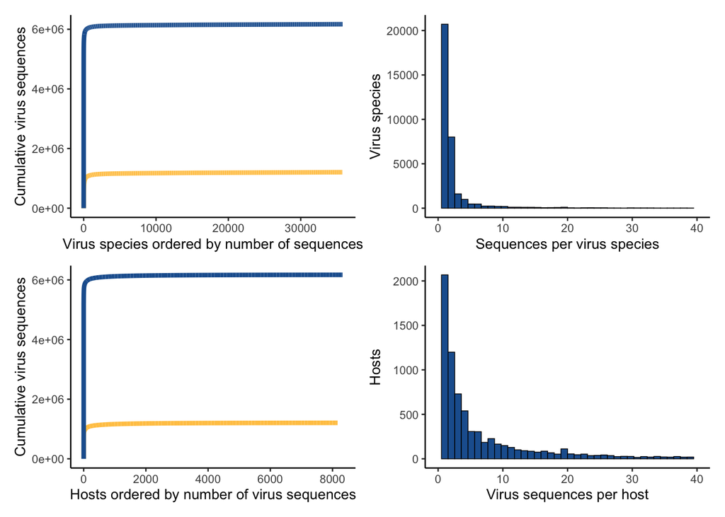

```r
# combine the plots into one 4-panel plot and save as a PDF
combined_p <- v_curve_p + v_histo_p + h_curve_p + h_histo_p

ggsave("Fig_1.pdf", combined_p, width=7.5, height=6, units="in", dpi=300)
combined_p
```

### Calculate info about how many viruses and hosts are represented by only a single host

Output text about how many virus species and hosts

```r
printf("In other words, at the same time that a few viruses account for most sequences, there are sequences from thousands of different viruses and hosts (%0.0f viral taxa and %0.0f hosts).",
       nrow(seqs_per_virus), nrow(seqs_per_host))
```

```
## [1] "In other words, at the same time that a few viruses account for most sequences, there are sequences from thousands of different viruses and hosts (35781 viral taxa and 8322 hosts)."
```

```r
# How many viruses or host have only a single virus sequence?
n_viruses_with_one_seq <- nrow(filter(seqs_per_virus, seqs_per_virus == 1))
f_viruses_with_one_seq <- n_viruses_with_one_seq / nrow(seqs_per_virus)
n_hosts_with_one_seq <- nrow(filter(seqs_per_host, seqs_per_host == 1))
f_hosts_with_one_seq <- n_hosts_with_one_seq / nrow(seqs_per_host)

# output text for paper
printf("The majority of viral taxa (%0.0f, %0.0f%%) are represented by a single sequence", n_viruses_with_one_seq, f_viruses_with_one_seq * 100)
```

```
## [1] "The majority of viral taxa (20712, 58%) are represented by a single sequence"
```

Calculate mean and median values:

```r
# summary stats for viruses per spp and host
mean_v_per_v <- seqs_per_virus %>% summarize(mean = mean(seqs_per_virus)) %>% pull(mean)
median_v_per_v <- seqs_per_virus %>% summarize(median = median(seqs_per_virus)) %>% pull(median)

mean_v_per_h <- seqs_per_host %>% summarize(mean = mean(seqs_per_host)) %>% pull(mean)
median_v_per_h <- seqs_per_host %>% summarize(median = median(seqs_per_host)) %>% pull(median)

# make some text for paper
printf("Although the mean number of viruses per virus species is %0.0f and the mean number of viruses per host is %0.0f, the median values are only %0.0f sequence per virus and %0.0f per host.", mean_v_per_v, mean_v_per_h, median_v_per_v, median_v_per_h)
```

```
## [1] "Although the mean number of viruses per virus species is 172 and the mean number of viruses per host is 741, the median values are only 1 sequence per virus and 4 per host."
```

### Identify random single-sequence hosts or viruses

Use the sample() function in R to pull out a random set of viruses or hosts with only one sequence. Every time you run this code it will produce a different random subset.

```r
# pull out some random examples of viruses and hosts with just one sequecne

v_one_seq <- filter(seqs_per_virus, seqs_per_virus == 1)
v_one_seq[sample(nrow(v_one_seq), 20), ]
```

```
## # A tibble: 20 × 4
##    Species                                  seqs_per_virus  rank cumulative_seqs
##    <chr>                                             <int> <int>           <int>
##  1 Pestivirus Giraffe-1                                  1 28332         6161921
##  2 Adenovirus PREDICT_AdV-81                             1 15400         6148989
##  3 Klebsiella phage KpnM6E1                              1 24181         6157770
##  4 Hubei partiti-like virus 44                           1 23249         6156838
##  5 Wenling crossorhombus astrovirus 2                    1 35329         6168918
##  6 Tomato yellow blotch virus                            1 34274         6167863
##  7 Gordonia phage Nina                                   1 22396         6155985
##  8 Microbacterium phage Vitas                            1 25717         6159306
##  9 Pika astrovirus Ot/FG164/Yunnan                       1 28732         6162321
## 10 Streptococcus phage Javan633                          1 33138         6166727
## 11 Jingmen birna-like virus                              1 23836         6157425
## 12 Picobirnavirus monkey/CHN-56/2002                     1 28589         6162178
## 13 Tomato begomovirus T217L                              1 34257         6167846
## 14 Streptococcus satellite phage Javan753                1 33690         6167279
## 15 Alphacoronavirus UKMa1                                1 15664         6149253
## 16 Escherichia phage skuden                              1 21169         6154758
## 17 Wenzhou Rattus norvegicus jeilongvirus 1              1 35440         6169029
## 18 Staphylococcus phage HSA30                            1 32311         6165900
## 19 Escherichia phage U115                                1 21205         6154794
## 20 Sanya polycipivirus 1                                 1 31574         6165163
```

```r
# hosts with one virus sequence
h_one_seq <- filter(seqs_per_host, seqs_per_host == 1)
h_one_seq[sample(nrow(h_one_seq), 20), ]
```

```
## # A tibble: 20 × 4
##    host_taxid seqs_per_host  rank cumulative_seqs
##    <chr>              <int> <int>           <int>
##  1 53323                  1  7748         6168796
##  2 41066                  1  7486         6168534
##  3 9453                   1  8275         6169323
##  4 76709                  1  8084         6169132
##  5 1125                   1  6343         6167391
##  6 369654                 1  7387         6168435
##  7 1089802                1  6323         6167371
##  8 2147                   1  6949         6167997
##  9 4454                   1  7568         6168616
## 10 1041208                1  6294         6167342
## 11 208206                 1  6920         6167968
## 12 59814                  1  7869         6168917
## 13 119403                 1  6397         6167445
## 14 52471                  1  7733         6168781
## 15 765959                 1  8081         6169129
## 16 82762                  1  8150         6169198
## 17 58645                  1  7842         6168890
## 18 8706                   1  8199         6169247
## 19 145752                 1  6563         6167611
## 20 20400                  1  6901         6167949
```

### What fraction of hosts have assigned virus sequences?

```r
# how many species of cellular organisms in the NCBI taxonomy?
# 131567 is the taxid for cellular organisms.  Archae, Bacteria, and Eukaryotes are children of this taxon.
cellular_species <- taxizedb::downstream(131567, downto='species')
n_cellular_spp <- nrow(cellular_species$`131567`)

# estimate of fraction of species diversity captubred by NCBI Taxonomy database.
# this estimate is listed on the NCBI Taxonomy homepage.
pct_diversity_represented <- 10

# how many species of viruses in the NCBI taxonomy?
virus_species <- taxizedb::downstream(10239, downto='species')
n_virus_spp <- nrow(virus_species$`10239`)
virus_sp_df <- virus_species$'10239'

pct_hosts_with_virus <- 100 * nrow(seqs_per_host) / n_cellular_spp / pct_diversity_represented

printf("There are records for %0.0f species of cellular life in the NCBI Taxonomy database. This captures only a small fraction — perhaps %0.0f%% — of actual species diversity, meaning that virus sequences have been described for only something like %0.1f%% of hosts (%0.0f/%0.0f/%0.0f).",
       n_cellular_spp,
       pct_diversity_represented,
       pct_hosts_with_virus,
       nrow(seqs_per_host),
       n_cellular_spp,
       (100/pct_diversity_represented))
```

```
## [1] "There are records for 626899 species of cellular life in the NCBI Taxonomy database. This captures only a small fraction — perhaps 10% — of actual species diversity, meaning that virus sequences have been described for only something like 0.1% of hosts (8322/626899/10)."
```

### Some content not in paper

You could extent this analysis in a number of ways. For instance, you could break out the # of sequences per virus/host combo:

### Split data by virus / host combinations

Order the data by virus-host combinations.

So, for instance, influenza a virus sequences will be separated into different counts based on their hosts

```r
df_virus_species_and_host <- df_host %>% group_by(Species, host_taxon_name) %>%
  summarize(n_virus_seq = n(),
            .groups="drop") %>%
  arrange(-n_virus_seq)

head(df_virus_species_and_host, 100)
```

```
## # A tibble: 100 × 3
##    Species                                               host_taxon_name n_virus_seq
##    <chr>                                                 <chr>                 <int>
##  1 Severe acute respiratory syndrome-related coronavirus Homo sapiens        3035490
##  2 Human immunodeficiency virus 1                        Homo sapiens         983691
##  3 Influenza A virus                                     Homo sapiens         378116
##  4 Hepacivirus C                                         Homo sapiens         153904
##  5 Influenza B virus                                     Homo sapiens         111969
##  6 Influenza A virus                                     Sus scrofa           101542
##  7 Hepatitis B virus                                     Homo sapiens          88741
##  8 Rotavirus A                                           Homo sapiens          74244
##  9 Influenza A virus                                     Gallus gallus         66763
## 10 Influenza A virus                                     Anas platyrhyn…       48870
## # … with 90 more rows
```